# Lesson notes | Histograms with {ggplot2}

# 1 Histograms with {ggplot2}

## 1.1 Learning Objectives

By the end of this lesson, you will be able to:

1. Plot a histogram to visualize the distribution of continuous variables using **`geom_histogram()`**.
2. Adjust the number or size of bins on a histogram by with the **`bins`** or **`binwidth`** arguments.
3. Shift and align bins on a histogram with the **`boundary`** argument.
4. Set bin boundaries to a sequence of values with the **`breaks`** argument.

## 1.2 Introduction

A histogram is a plot that visualizes the *distribution* of a numerical value as follows:

1. We first cut up the x-axis into a series of *bins*, where each bin represents a range of values.
2. For each bin, we count the number of observations that fall in the range corresponding to that bin.
3. Then for each bin, we draw a bar whose height marks the corresponding count.

## 1.3 Packages

```r
pacman::p_load(tidyverse,
               here)
```

## 1.4 Childhood diarrheal diseases in Mali

We will visualize distributions of numerical variables in the `malidd` data frame, which we’ve seen in previous lessons.

```r
# Import data from CSV
malidd <- read_csv(here::here("data/clean/malidd.csv"))
```

These data were collected as part of an observational study of acute diarrhea in children aged 0-59 months. The study was conducted in Mali and in early 2020. The dataset records demographic and clinical information for 150 patients.

```r
# View first few rows of the data frame
head(malidd)
```

| n | admit_date | sex | age_months | height_cm | muac_cm | breastfeeding | vomit | fever | bloody_stool | temp | freqrespi | viral_load | diarrhea_days | diarrhea_episodes | medication | trad_medication | commune | mother_education | father_education | household_size |
| --- | --- | --- | --- | --- | --- | --- | --- | --- | --- | --- | --- | --- | --- | --- | --- | --- | --- | --- | --- | --- |
| 1 | 2020-01-16 | M | 5 | 61.2 | 11.3 | 1 | 0 | 0 | 0 | 35.3 | 42 | 0.5727 | 3 | 6 | 0 | 1 | Golobougou | 0 | 0 | 30 |
| 2 | 2020-01-17 | F | 12 | 70.6 | 13.2 | 1 | 1 | 1 | 0 | 36.7 | 32 | 0.7362 | 4 | 5 | 1 | 1 | Kalaban-Coura | 13 | 0 | 6 |
| 3 | 2020-01-17 | M | 11 | 71.1 | 13.5 | 1 | 1 | 0 | 0 | 35.8 | 60 | 0.5536 | 2 | 3 | 0 | 0 | Kalabancoura | 13 | 16 | 22 |
| 4 | 2020-01-17 | M | 9 | 68.5 | 12.6 | 1 | 0 | 0 | 0 | 35.8 | 50 | 0.5536 | 3 | 5 | 0 | 1 | Quartier-Mali | 0 | 0 | 20 |
| 5 | 2020-01-21 | F | 16 | 78.7 | 14.2 | 1 | 1 | 0 | 0 | 36.4 | 42 | 0.7304 | 0 | 3 | 0 | 0 | Kabala | 13 | 17 | 8 |
| 6 | 2020-01-21 | M | 6 | 67.7 | 14.5 | 1 | 0 | 0 | 0 | 35.7 | 52 | 0.666 | 0 | 5 | 0 | 0 | Kalabancoura | 13 | 15 | 3 |

The dataframe has 21 variables, many of which are continuous, like `height_cm`, `viral_load`, and `freqrespi`.

## 1.5 Basic histograms with `geom_histogram()`

Now let’s use {ggplot2} to plot the distribution of childrens’ heights, which is recorded in the `heigh_cm` column of `malidd`.

The `geom_*()` function used for histograms is **`geom_histogram()`**

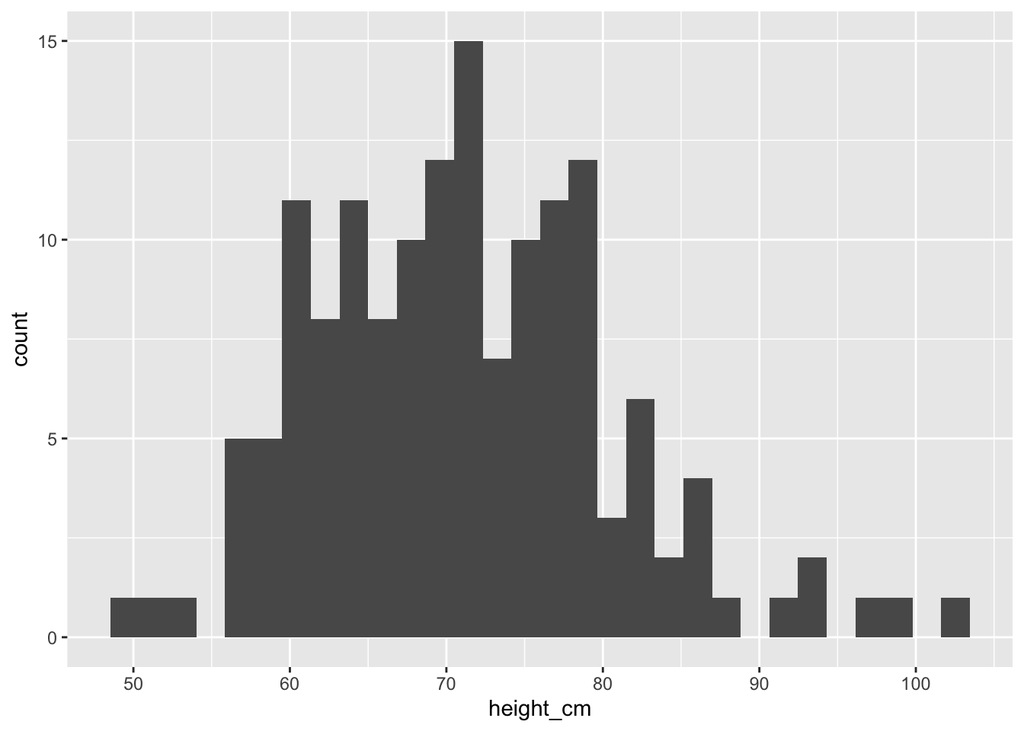

```r
# Simple histogram showing the distribution of height_cm
ggplot(data = malidd,
       mapping = aes(x = height_cm)) +
  geom_histogram()
```

If we don’t adjust the bins in `geom_histogram()`, we get a warning message. You can ignore this warning message for now, and will learn how to customize bins in the next section.

In the previous histogram, it’s hard to where the boundaries for each bin start and end since everything is one big amorphous blob. So let’s add borders around the bins:

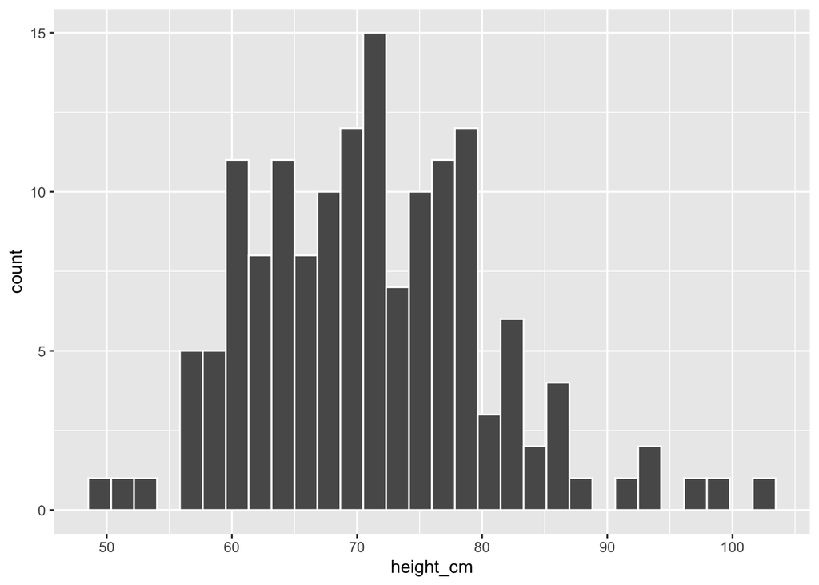

```r
# Set border color to "white"
ggplot(data =  malidd ,
       mapping = aes(x = height_cm)) +
  geom_histogram(color = "white")
```

We now have an easier time associating ranges of cases to each of the bins.

We can also vary the color of the bars by setting the `fill` argument:

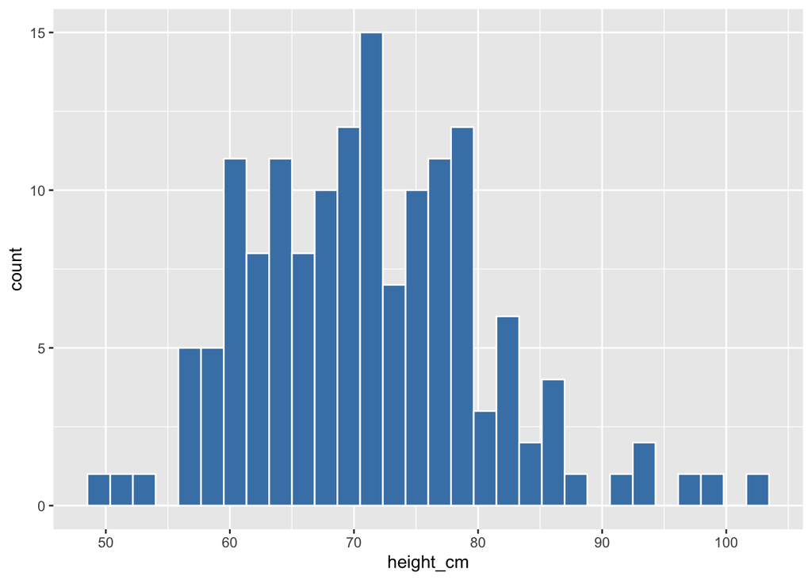

```r
# Set fill color to "steelblue"
ggplot(data =  malidd ,
       mapping = aes(x = height_cm)) +
  geom_histogram(color = "white",
                 fill = "steelblue")
```

Now that we can see the bars more clearly, let’s unpack the resulting histogram. Some questions we might want to answer are:

1. What are the smallest and largest values?
2. What is the “center” or “most typical” value?
3. How do the values spread out?
4. What are frequent and infrequent values?

We can see that heights range from 50 to 105cm. The center is around 70cm, most patients fall in the 60-80cm range, with very few below 55cm or above 90cm. Observe that the histogram has a bell shape, meaning that the variable has a *normal distribution* (more or less).

- Plot a histogram showing the distribution of age (`age_months`) in `malidd`. Make the borders and fill of the bars “seagreen”, and reduce opacity to 40%.
- Building on your code for the previous plot, modify the axis titles to “Age (months)” and “Number of children”, respectively.

## 1.6 Adjusting bins in a histogram

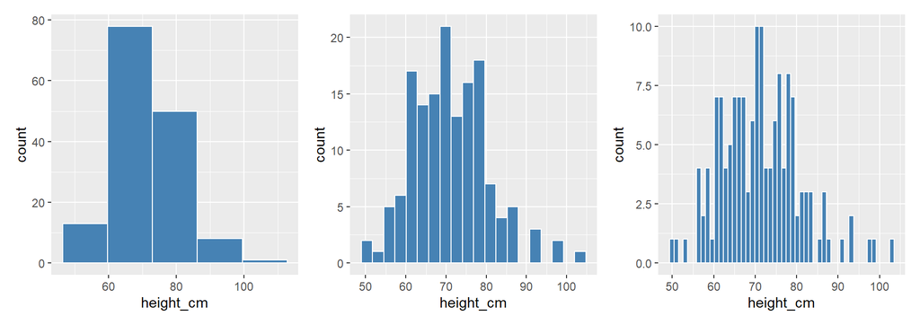

Histograms plotting the same variable with different bin settings.

After running code in previous examples, we got a histogram as well as a warning message about bins and bin width. The warning message is telling us that the histogram was constructed using `bins = 30` for 30 equally spaced bins.

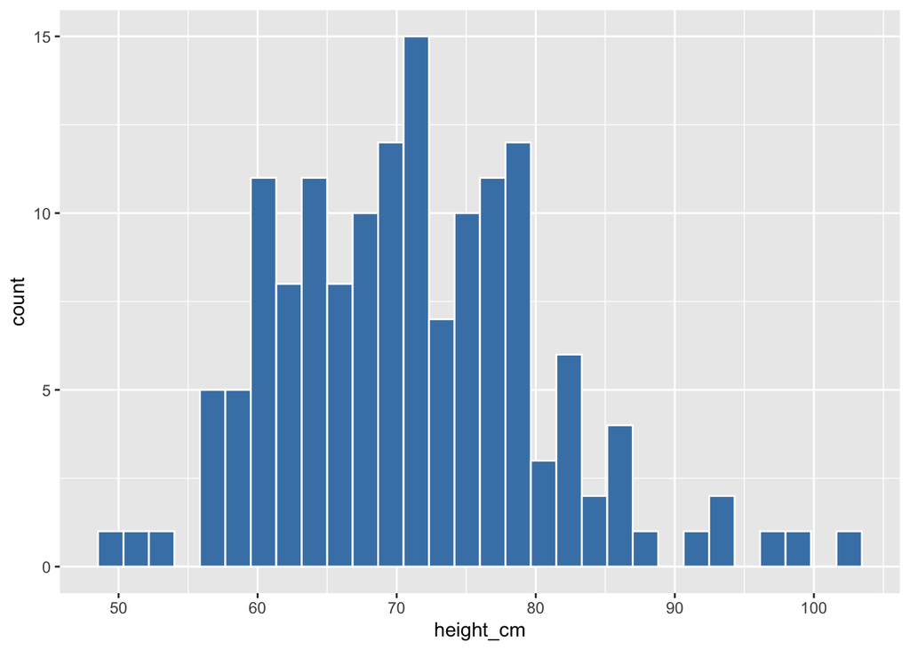

```r
# Warning message tells us to change the default of 30 bins
ggplot(data =  malidd ,
       mapping = aes(x = height_cm)) +
  geom_histogram(color = "white",
                 fill = "steelblue")
```

Unless you override this default number of bins with a number you specify, R will keep giving this message.

We can change the number of bins to another value using one of these three arguments to `geom_histogram()`:

1. Set the number of bins with **`bins`**
2. Set the width of the bins with **`binwidth`**
3. Set bin boundaries **`breaks`**

### 1.6.1 Set the number of bins with `bins`

Using the first method, we have the power to specify how many bins we would like to cut the x-axis up in by setting `bins = INTEGER`:

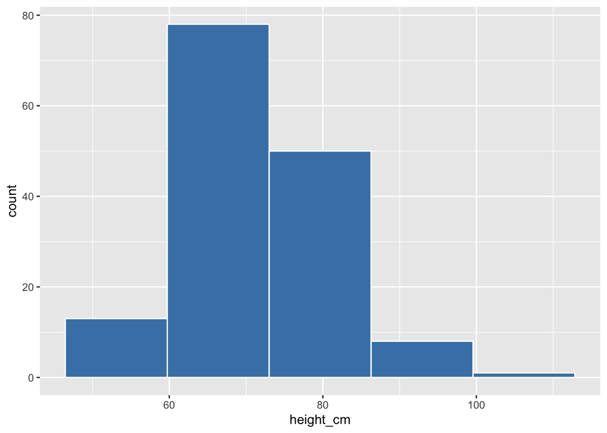

```r
# Try different numbers of bins

ggplot(data =  malidd ,
       mapping = aes(x = height_cm)) +
  geom_histogram(bins = 5,
                 color = "white",
                 fill = "steelblue")
```

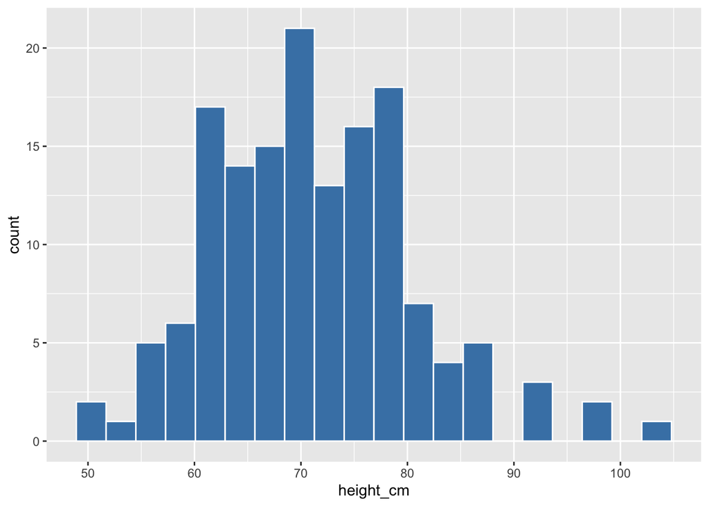

```r
ggplot(data =  malidd ,
       mapping = aes(x = height_cm)) +
  geom_histogram(bins = 20,
                 color = "white",
                 fill = "steelblue")
```

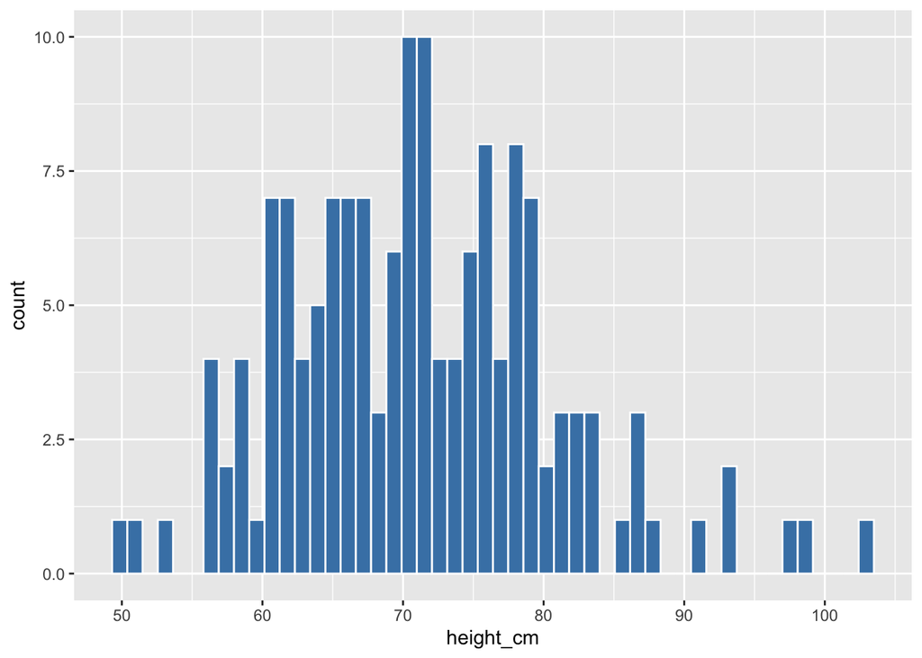

```r
ggplot(data =  malidd ,
       mapping = aes(x = height_cm)) +
  geom_histogram(bins = 50,
                 color = "white",
                 fill = "steelblue")
```

Make a histogram of frequency of respiration (`freqrespi`), which is measured in breaths per minute. Set the interior color to “indianred3”, and border color to “lightgray”.

Notice that with the default of 30 bins, there are some intervals for which no bar is plotted (i.e., there were no observations in that range).

Low the number of bins until there are no empty intervals. You should choose the highest value of bins for which there are no empty spaces.

### 1.6.2 Set the width of bins with `binwidth`

Using the second method, instead of specifying the number of bins, we specify the width of the bins by using the `binwidth` argument in `geom_histogram()`.

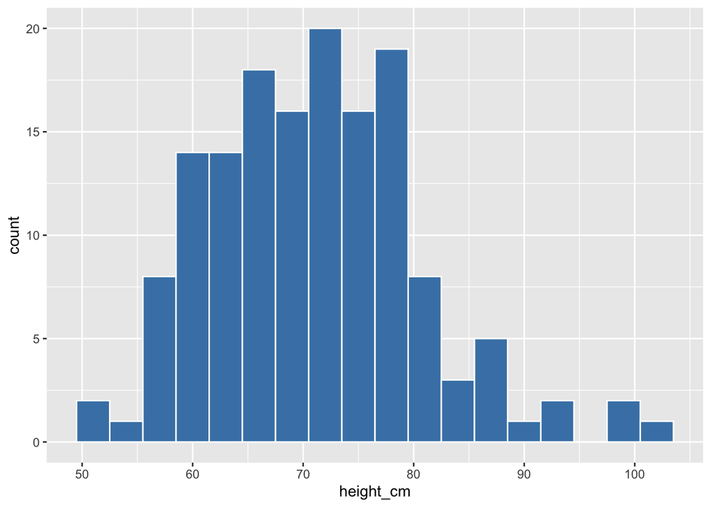

```r
# Try different bin widths
ggplot(data =  malidd,
       mapping = aes(x = height_cm)) +
  geom_histogram(color = "white",
                 fill = "steelblue",
                 binwidth = 3)
```

Looking at the range of the variable can help us choose an appropriate bin width.

```r
range(malidd$height_cm)
```

```
## [1]  50.3 103.4
```

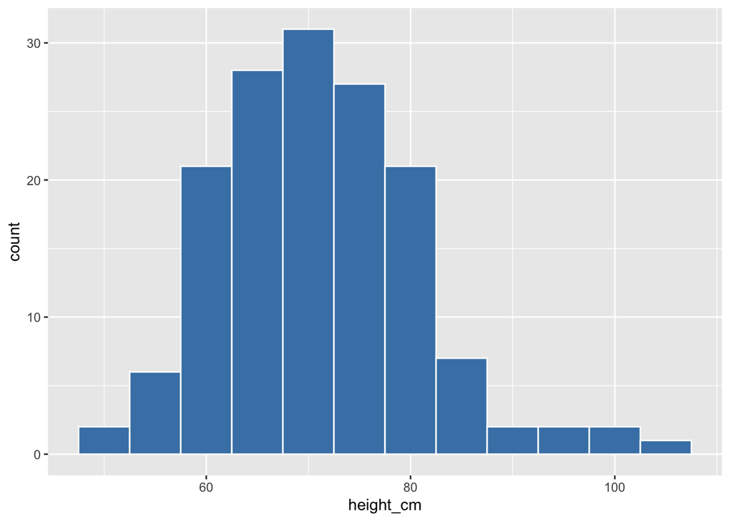

```r
ggplot(data =  malidd,
       mapping = aes(x = height_cm)) +
  geom_histogram(color = "white",
                 fill = "steelblue",
                 binwidth = 5)
```

We can use the `boundary` argument to align the bins to the x-axis intervals.

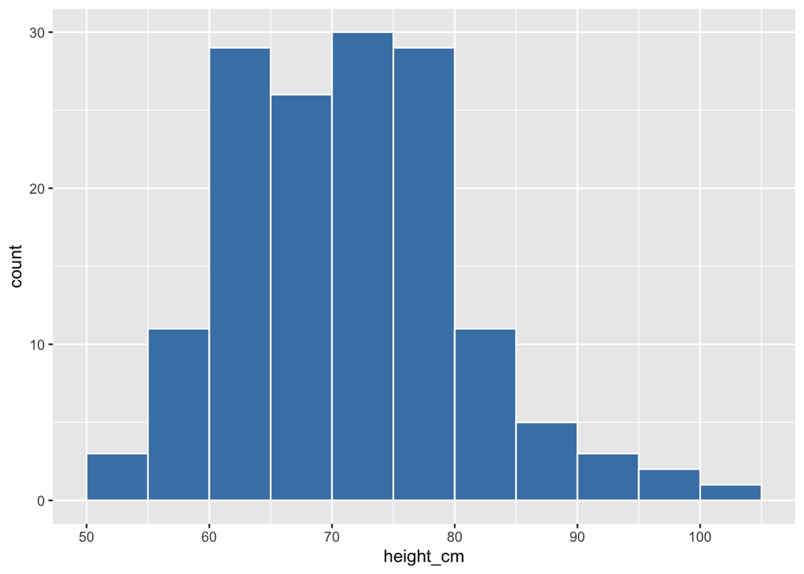

```r
# Set `boundary` equal to the low end of the variable
ggplot(data =  malidd,
       mapping = aes(x = height_cm)) +
  geom_histogram(color = "white",
                 fill = "steelblue",
                 binwidth = 5,
                 boundary = 50)
```

Create the same `freqrespi` histogram from the last practice question, but this time set the bin width to to a value that results in 18 bins. Then align the bars to the x axis breaks by adjusting the bin boundaries.

### 1.6.3 Modify bin boundaries with `breaks`

Set `breaks` equal to a **numeric vector** in `geom_histogram()`:

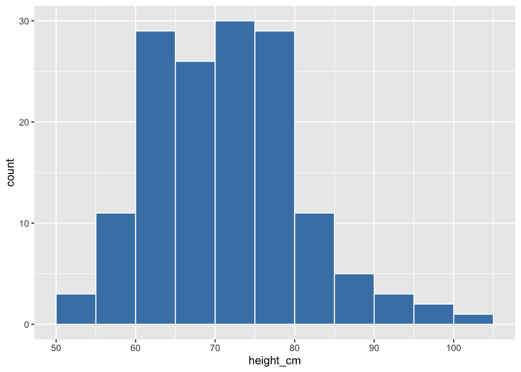

```r
# Supply a vector that covers the range of values in height_cm
ggplot(data =  malidd,
       mapping = aes(x = height_cm)) +
  geom_histogram(color = "white",
                 fill = "steelblue",
                 breaks = seq(50, 105, 5))
```

Plot the `freqrespi` histogram with bin breaks that range from the lowest value of `freqrespi` to the highest, with intervals of 4.

Next, adjust the x-axis scale breaks by adding a `scale_*()` function. Set the range to 24-60, with an intervals of 8.

## 1.7 Summary

Histograms, unlike scatterplots and linegraphs, present information on only a single numerical variable. Specifically, they are visualizations of the distribution of the numerical variable in question.

## Contributors

The following team members contributed to this lesson:

- [JOY VAZ](https://thegraphcourses.org/members/joy)  
  R Developer and Instructor, the GRAPH Network

  Loves doing science and teaching science
- [ADMIN TEAM](https://thegraphnetwork.training/members/admin/)  
  GRAPH Courses Administration Team

  The GRAPH Courses team is building epidemiological training courses to enhance disease surveillance and data science for public health across the globe

## References

Some material in this lesson was adapted from the following sources:

- Ismay, Chester, and Albert Y. Kim. 2022. *A ModernDive into R and the Tidyverse*. https://moderndive.com/.
- Chang, Winston. 2013. *R Graphics Cookbook: Practical Recipes for Visualizing Data*. 1st edition. Beijing Köln: O’Reilly Media.

This work is licensed under the [Creative Commons Attribution Share Alike](https://creativecommons.org/licenses/by-sa/4.0/) license.